# Comparando a maturidade sexual morfológica

Gabriel F. B. Rodrigues

7 de agosto de 2020

## Maturidade Sexual

A maturidade sexual pode ser entendida como a transição de um organismo do estado jovem (inapto a se reproduzir) para adulto (apto a reprodução). Portanto, essa questão é muito importante para medidas de conservação de espécies, como por exemplo o estabelecimento de um tamanho mínimo para pescados. O tamanho da maturidade sexual pode variar entre espécies e até mesmo entre populações da mesma espécie. Por exemplo, indivíduos de populações que vivem em um ambiente rico em alimento e com maiores temperaturas podem crescer mais rápido do que indivíduos que vivem em ambientes mais severos. Essa proposta foi amplamente discutida por Wenner, Fusaro, and Oaten (1974), onde utilizava o tamanho médio mínimo de fêmeas com ovos no abdome para estipular o tamanho da maturidade sexual de uma população.

## Calculando a maturidade sexual

Tendo em vista que dentro de uma população alguns indivíduos vão se tornar "adultos" em maiores tamanhos e alguns em menores tamanhos, enquanto a maioria isso irá acontecer em tamanhos intermediários. Assim podemos assumir uma distribuição normal para o tamanho dos indivíduos de uma população.

```r
#Gerando um data frame de distribuição normal para individuos de uma população de caranguejos. Note que LC = Largura da Carapaça em centímetros. E que o fator Adulto é representado por digitos binários onde 0 = Jovem e 1 = Adulto
Jovens<- rnorm(n = 50, mean = 10, sd = 2)
Adultos<- rnorm(n = 50, mean = 15, sd = 2)
df<- data.frame(LC = c(Jovens, Adultos), Maturidade = c(rep("Jovem", 50), rep("Adulto", 50)), Adulto = c(rep(0,50), rep(1,50)))
```

```r
LC50 = (log(.5/(1-.5)) - coef(model1)[1])/coef(model1)[2]
LC50
```

```
## (Intercept)
##    12.80408
```

### Representando graficamente

Podemos representar graficamente a distribuição da função encontrada pelo modelo e ainda o valor de LC50 obtido.

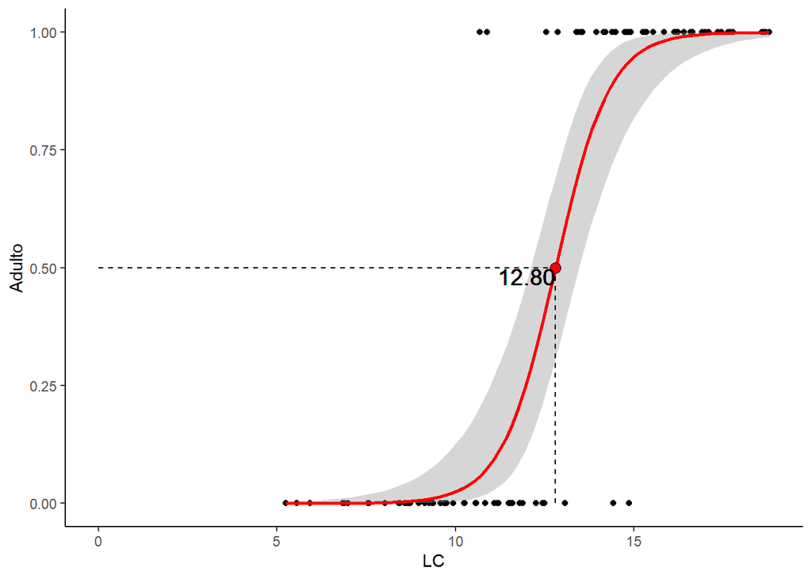

```r
#Plotando o gráfico
require(ggplot2)
ggplot(data=df, aes(x=LC, y=Adulto, label = LC50))+
  geom_point()+
  geom_smooth(method = 'glm', method.args = list(family = "binomial"), se=T, col="red")+
  geom_segment(lty = 2, aes(x = 0, y = .5, xend = LC50, yend = .5))+
  geom_segment(lty=2,aes(x = LC50, y = 0, xend = LC50, yend = 0.5))+
  geom_point(x = LC50, y = 0.5, size = 3, shape =21, fill = "red" ) +
  geom_text(label = sprintf(LC50, fmt = '%#.2f'), x = LC50, y = 0.5, hjust=1,vjust=1, size = 5) +
  theme_classic()
```

Qualquer dúvida, correção ou sugestão pode ser encaminhada para gfellipe5@gmail.com

# Referências

Wenner, Adrian M, Craig Fusaro, and Allan Oaten. 1974. “Size at Onset of Sexual Maturity and Growth Rate in Crustacean Populations.” *Canadian Journal of Zoology* 52 (9). NRC Research Press: 1095–1106.